# Risk Factor Analysis

## Outcome Variable

**Outcome Variable:** y_rate_len

## Predictor Variables

**Intervention Variable:** pers_wast

**Adjustment Set:**

unadjusted

## Stratifying Variables

The analysis was stratified on these variable(s):

- agecat
- studyid
- country

## Data Summary

| agecat | studyid | country | pers_wast | n_cell | n |
| --- | --- | --- | --- | --- | --- |
| 0-3 months | CMC-V-BCS-2002 | INDIA | 0 | 79 | 88 |
| 0-3 months | CMC-V-BCS-2002 | INDIA | 1 | 9 | 88 |
| 0-3 months | CMIN | BANGLADESH | 0 | 41 | 43 |
| 0-3 months | CMIN | BANGLADESH | 1 | 2 | 43 |
| 0-3 months | CONTENT | PERU | 0 | 29 | 29 |
| 0-3 months | CONTENT | PERU | 1 | 0 | 29 |
| 0-3 months | EE | PAKISTAN | 0 | 284 | 303 |
| 0-3 months | EE | PAKISTAN | 1 | 19 | 303 |
| 0-3 months | GMS-Nepal | NEPAL | 0 | 450 | 509 |
| 0-3 months | GMS-Nepal | NEPAL | 1 | 59 | 509 |
| 0-3 months | IRC | INDIA | 0 | 310 | 376 |
| 0-3 months | IRC | INDIA | 1 | 66 | 376 |
| 0-3 months | Keneba | GAMBIA | 0 | 1217 | 1257 |
| 0-3 months | Keneba | GAMBIA | 1 | 40 | 1257 |
| 0-3 months | MAL-ED | BANGLADESH | 0 | 236 | 243 |
| 0-3 months | MAL-ED | BANGLADESH | 1 | 7 | 243 |
| 0-3 months | MAL-ED | BRAZIL | 0 | 168 | 168 |
| 0-3 months | MAL-ED | BRAZIL | 1 | 0 | 168 |
| 0-3 months | MAL-ED | INDIA | 0 | 170 | 183 |
| 0-3 months | MAL-ED | INDIA | 1 | 13 | 183 |
| 0-3 months | MAL-ED | NEPAL | 0 | 154 | 156 |
| 0-3 months | MAL-ED | NEPAL | 1 | 2 | 156 |
| 0-3 months | MAL-ED | PERU | 0 | 265 | 265 |
| 0-3 months | MAL-ED | PERU | 1 | 0 | 265 |
| 0-3 months | MAL-ED | SOUTH AFRICA | 0 | 209 | 211 |
| 0-3 months | MAL-ED | SOUTH AFRICA | 1 | 2 | 211 |
| 0-3 months | MAL-ED | TANZANIA, UNITED REPUBLIC OF | 0 | 228 | 228 |
| 0-3 months | MAL-ED | TANZANIA, UNITED REPUBLIC OF | 1 | 0 | 228 |
| 0-3 months | PROVIDE | BANGLADESH | 0 | 625 | 640 |
| 0-3 months | PROVIDE | BANGLADESH | 1 | 15 | 640 |

[output cut: 238 more lines]

The following strata were considered:

- agecat: 0-3 months, studyid: CMC-V-BCS-2002, country: INDIA
- agecat: 0-3 months, studyid: CMIN, country: BANGLADESH
- agecat: 0-3 months, studyid: CONTENT, country: PERU
- agecat: 0-3 months, studyid: EE, country: PAKISTAN
- agecat: 0-3 months, studyid: GMS-Nepal, country: NEPAL
- agecat: 0-3 months, studyid: IRC, country: INDIA
- agecat: 0-3 months, studyid: Keneba, country: GAMBIA
- agecat: 0-3 months, studyid: MAL-ED, country: BANGLADESH
- agecat: 0-3 months, studyid: MAL-ED, country: BRAZIL
- agecat: 0-3 months, studyid: MAL-ED, country: INDIA
- agecat: 0-3 months, studyid: MAL-ED, country: NEPAL
- agecat: 0-3 months, studyid: MAL-ED, country: PERU
- agecat: 0-3 months, studyid: MAL-ED, country: SOUTH AFRICA
- agecat: 0-3 months, studyid: MAL-ED, country: TANZANIA, UNITED REPUBLIC OF
- agecat: 0-3 months, studyid: PROVIDE, country: BANGLADESH
- agecat: 0-3 months, studyid: ResPak, country: PAKISTAN
- agecat: 12-15 months, studyid: CMC-V-BCS-2002, country: INDIA
- agecat: 12-15 months, studyid: CMIN, country: BANGLADESH
- agecat: 12-15 months, studyid: CONTENT, country: PERU
- agecat: 12-15 months, studyid: EE, country: PAKISTAN
- agecat: 12-15 months, studyid: GMS-Nepal, country: NEPAL
- agecat: 12-15 months, studyid: Guatemala BSC, country: GUATEMALA
- agecat: 12-15 months, studyid: IRC, country: INDIA
- agecat: 12-15 months, studyid: Keneba, country: GAMBIA
- agecat: 12-15 months, studyid: MAL-ED, country: BANGLADESH
- agecat: 12-15 months, studyid: MAL-ED, country: BRAZIL
- agecat: 12-15 months, studyid: MAL-ED, country: INDIA
- agecat: 12-15 months, studyid: MAL-ED, country: NEPAL
- agecat: 12-15 months, studyid: MAL-ED, country: PERU
- agecat: 12-15 months, studyid: MAL-ED, country: SOUTH AFRICA
- agecat: 12-15 months, studyid: MAL-ED, country: TANZANIA, UNITED REPUBLIC OF
- agecat: 12-15 months, studyid: PROVIDE, country: BANGLADESH
- agecat: 12-15 months, studyid: ResPak, country: PAKISTAN
- agecat: 12-15 months, studyid: TanzaniaChild2, country: TANZANIA, UNITED REPUBLIC OF
- agecat: 15-18 months, studyid: CMC-V-BCS-2002, country: INDIA
- agecat: 15-18 months, studyid: CMIN, country: BANGLADESH
- agecat: 15-18 months, studyid: CONTENT, country: PERU
- agecat: 15-18 months, studyid: EE, country: PAKISTAN
- agecat: 15-18 months, studyid: GMS-Nepal, country: NEPAL
- agecat: 15-18 months, studyid: IRC, country: INDIA
- agecat: 15-18 months, studyid: Keneba, country: GAMBIA
- agecat: 15-18 months, studyid: MAL-ED, country: BANGLADESH
- agecat: 15-18 months, studyid: MAL-ED, country: BRAZIL
- agecat: 15-18 months, studyid: MAL-ED, country: INDIA
- agecat: 15-18 months, studyid: MAL-ED, country: NEPAL
- agecat: 15-18 months, studyid: MAL-ED, country: PERU
- agecat: 15-18 months, studyid: MAL-ED, country: SOUTH AFRICA
- agecat: 15-18 months, studyid: MAL-ED, country: TANZANIA, UNITED REPUBLIC OF
- agecat: 15-18 months, studyid: PROVIDE, country: BANGLADESH
- agecat: 15-18 months, studyid: TanzaniaChild2, country: TANZANIA, UNITED REPUBLIC OF
- agecat: 18-21 months, studyid: CMC-V-BCS-2002, country: INDIA
- agecat: 18-21 months, studyid: CMIN, country: BANGLADESH
- agecat: 18-21 months, studyid: CONTENT, country: PERU
- agecat: 18-21 months, studyid: EE, country: PAKISTAN
- agecat: 18-21 months, studyid: GMS-Nepal, country: NEPAL
- agecat: 18-21 months, studyid: IRC, country: INDIA
- agecat: 18-21 months, studyid: Keneba, country: GAMBIA
- agecat: 18-21 months, studyid: MAL-ED, country: BANGLADESH
- agecat: 18-21 months, studyid: MAL-ED, country: BRAZIL
- agecat: 18-21 months, studyid: MAL-ED, country: INDIA
- agecat: 18-21 months, studyid: MAL-ED, country: NEPAL
- agecat: 18-21 months, studyid: MAL-ED, country: PERU
- agecat: 18-21 months, studyid: MAL-ED, country: SOUTH AFRICA
- agecat: 18-21 months, studyid: MAL-ED, country: TANZANIA, UNITED REPUBLIC OF
- agecat: 18-21 months, studyid: PROVIDE, country: BANGLADESH
- agecat: 18-21 months, studyid: TanzaniaChild2, country: TANZANIA, UNITED REPUBLIC OF
- agecat: 21-24 months, studyid: CMC-V-BCS-2002, country: INDIA
- agecat: 21-24 months, studyid: CMIN, country: BANGLADESH
- agecat: 21-24 months, studyid: CONTENT, country: PERU
- agecat: 21-24 months, studyid: EE, country: PAKISTAN
- agecat: 21-24 months, studyid: GMS-Nepal, country: NEPAL
- agecat: 21-24 months, studyid: IRC, country: INDIA
- agecat: 21-24 months, studyid: Keneba, country: GAMBIA
- agecat: 21-24 months, studyid: MAL-ED, country: BANGLADESH
- agecat: 21-24 months, studyid: MAL-ED, country: BRAZIL
- agecat: 21-24 months, studyid: MAL-ED, country: INDIA
- agecat: 21-24 months, studyid: MAL-ED, country: NEPAL
- agecat: 21-24 months, studyid: MAL-ED, country: PERU
- agecat: 21-24 months, studyid: MAL-ED, country: SOUTH AFRICA
- agecat: 21-24 months, studyid: MAL-ED, country: TANZANIA, UNITED REPUBLIC OF
- agecat: 21-24 months, studyid: PROVIDE, country: BANGLADESH
- agecat: 3-6 months, studyid: CMC-V-BCS-2002, country: INDIA
- agecat: 3-6 months, studyid: CMIN, country: BANGLADESH
- agecat: 3-6 months, studyid: CONTENT, country: PERU
- agecat: 3-6 months, studyid: EE, country: PAKISTAN
- agecat: 3-6 months, studyid: GMS-Nepal, country: NEPAL
- agecat: 3-6 months, studyid: IRC, country: INDIA
- agecat: 3-6 months, studyid: Keneba, country: GAMBIA
- agecat: 3-6 months, studyid: MAL-ED, country: BANGLADESH
- agecat: 3-6 months, studyid: MAL-ED, country: BRAZIL
- agecat: 3-6 months, studyid: MAL-ED, country: INDIA
- agecat: 3-6 months, studyid: MAL-ED, country: NEPAL
- agecat: 3-6 months, studyid: MAL-ED, country: PERU
- agecat: 3-6 months, studyid: MAL-ED, country: SOUTH AFRICA
- agecat: 3-6 months, studyid: MAL-ED, country: TANZANIA, UNITED REPUBLIC OF
- agecat: 3-6 months, studyid: PROVIDE, country: BANGLADESH
- agecat: 3-6 months, studyid: ResPak, country: PAKISTAN
- agecat: 3-6 months, studyid: TanzaniaChild2, country: TANZANIA, UNITED REPUBLIC OF
- agecat: 6-9 months, studyid: CMC-V-BCS-2002, country: INDIA
- agecat: 6-9 months, studyid: CMIN, country: BANGLADESH
- agecat: 6-9 months, studyid: CONTENT, country: PERU
- agecat: 6-9 months, studyid: EE, country: PAKISTAN
- agecat: 6-9 months, studyid: GMS-Nepal, country: NEPAL
- agecat: 6-9 months, studyid: Guatemala BSC, country: GUATEMALA
- agecat: 6-9 months, studyid: IRC, country: INDIA
- agecat: 6-9 months, studyid: Keneba, country: GAMBIA
- agecat: 6-9 months, studyid: MAL-ED, country: BANGLADESH
- agecat: 6-9 months, studyid: MAL-ED, country: BRAZIL
- agecat: 6-9 months, studyid: MAL-ED, country: INDIA
- agecat: 6-9 months, studyid: MAL-ED, country: NEPAL
- agecat: 6-9 months, studyid: MAL-ED, country: PERU
- agecat: 6-9 months, studyid: MAL-ED, country: SOUTH AFRICA
- agecat: 6-9 months, studyid: MAL-ED, country: TANZANIA, UNITED REPUBLIC OF
- agecat: 6-9 months, studyid: PROVIDE, country: BANGLADESH
- agecat: 6-9 months, studyid: ResPak, country: PAKISTAN
- agecat: 6-9 months, studyid: TanzaniaChild2, country: TANZANIA, UNITED REPUBLIC OF
- agecat: 9-12 months, studyid: CMC-V-BCS-2002, country: INDIA
- agecat: 9-12 months, studyid: CMIN, country: BANGLADESH
- agecat: 9-12 months, studyid: CONTENT, country: PERU
- agecat: 9-12 months, studyid: EE, country: PAKISTAN
- agecat: 9-12 months, studyid: GMS-Nepal, country: NEPAL
- agecat: 9-12 months, studyid: Guatemala BSC, country: GUATEMALA
- agecat: 9-12 months, studyid: IRC, country: INDIA
- agecat: 9-12 months, studyid: Keneba, country: GAMBIA
- agecat: 9-12 months, studyid: MAL-ED, country: BANGLADESH
- agecat: 9-12 months, studyid: MAL-ED, country: BRAZIL
- agecat: 9-12 months, studyid: MAL-ED, country: INDIA
- agecat: 9-12 months, studyid: MAL-ED, country: NEPAL
- agecat: 9-12 months, studyid: MAL-ED, country: PERU
- agecat: 9-12 months, studyid: MAL-ED, country: SOUTH AFRICA
- agecat: 9-12 months, studyid: MAL-ED, country: TANZANIA, UNITED REPUBLIC OF
- agecat: 9-12 months, studyid: PROVIDE, country: BANGLADESH
- agecat: 9-12 months, studyid: ResPak, country: PAKISTAN
- agecat: 9-12 months, studyid: TanzaniaChild2, country: TANZANIA, UNITED REPUBLIC OF

### Dropped Strata

- agecat: 0-3 months, studyid: CMIN, country: BANGLADESH
- agecat: 0-3 months, studyid: CONTENT, country: PERU
- agecat: 0-3 months, studyid: MAL-ED, country: BRAZIL
- agecat: 0-3 months, studyid: MAL-ED, country: NEPAL
- agecat: 0-3 months, studyid: MAL-ED, country: PERU
- agecat: 0-3 months, studyid: MAL-ED, country: SOUTH AFRICA
- agecat: 0-3 months, studyid: MAL-ED, country: TANZANIA, UNITED REPUBLIC OF
- agecat: 3-6 months, studyid: CONTENT, country: PERU
- agecat: 3-6 months, studyid: MAL-ED, country: BRAZIL
- agecat: 3-6 months, studyid: MAL-ED, country: PERU
- agecat: 3-6 months, studyid: MAL-ED, country: SOUTH AFRICA
- agecat: 3-6 months, studyid: MAL-ED, country: TANZANIA, UNITED REPUBLIC OF
- agecat: 6-9 months, studyid: CMIN, country: BANGLADESH
- agecat: 6-9 months, studyid: CONTENT, country: PERU
- agecat: 6-9 months, studyid: Guatemala BSC, country: GUATEMALA
- agecat: 6-9 months, studyid: MAL-ED, country: BANGLADESH
- agecat: 6-9 months, studyid: MAL-ED, country: BRAZIL
- agecat: 6-9 months, studyid: MAL-ED, country: PERU
- agecat: 6-9 months, studyid: MAL-ED, country: SOUTH AFRICA
- agecat: 6-9 months, studyid: MAL-ED, country: TANZANIA, UNITED REPUBLIC OF
- agecat: 9-12 months, studyid: CMIN, country: BANGLADESH
- agecat: 9-12 months, studyid: CONTENT, country: PERU
- agecat: 9-12 months, studyid: Guatemala BSC, country: GUATEMALA
- agecat: 9-12 months, studyid: MAL-ED, country: BRAZIL
- agecat: 9-12 months, studyid: MAL-ED, country: PERU
- agecat: 9-12 months, studyid: MAL-ED, country: SOUTH AFRICA
- agecat: 9-12 months, studyid: MAL-ED, country: TANZANIA, UNITED REPUBLIC OF
- agecat: 12-15 months, studyid: CONTENT, country: PERU
- agecat: 12-15 months, studyid: Guatemala BSC, country: GUATEMALA
- agecat: 12-15 months, studyid: MAL-ED, country: BRAZIL
- agecat: 12-15 months, studyid: MAL-ED, country: PERU
- agecat: 12-15 months, studyid: MAL-ED, country: SOUTH AFRICA
- agecat: 12-15 months, studyid: MAL-ED, country: TANZANIA, UNITED REPUBLIC OF
- agecat: 15-18 months, studyid: CONTENT, country: PERU
- agecat: 15-18 months, studyid: MAL-ED, country: BRAZIL
- agecat: 15-18 months, studyid: MAL-ED, country: PERU
- agecat: 15-18 months, studyid: MAL-ED, country: SOUTH AFRICA
- agecat: 15-18 months, studyid: MAL-ED, country: TANZANIA, UNITED REPUBLIC OF
- agecat: 18-21 months, studyid: CONTENT, country: PERU
- agecat: 18-21 months, studyid: MAL-ED, country: BRAZIL
- agecat: 18-21 months, studyid: MAL-ED, country: PERU
- agecat: 18-21 months, studyid: MAL-ED, country: SOUTH AFRICA
- agecat: 18-21 months, studyid: MAL-ED, country: TANZANIA, UNITED REPUBLIC OF
- agecat: 18-21 months, studyid: TanzaniaChild2, country: TANZANIA, UNITED REPUBLIC OF
- agecat: 21-24 months, studyid: CMIN, country: BANGLADESH
- agecat: 21-24 months, studyid: CONTENT, country: PERU
- agecat: 21-24 months, studyid: MAL-ED, country: BRAZIL
- agecat: 21-24 months, studyid: MAL-ED, country: PERU
- agecat: 21-24 months, studyid: MAL-ED, country: SOUTH AFRICA
- agecat: 21-24 months, studyid: MAL-ED, country: TANZANIA, UNITED REPUBLIC OF

## Methods Detail

We’re interested in the causal parameters $E[Y_a]$ for all values of $a \in \mathcal{A}$. These parameters represent the mean outcome if, possibly contrary to fact, we intervened to set all units to have $A=a$. Under the randomization and positivity assumptions, these are identified by the statistical parameters $\psi_a=E_W[E_{Y|A,W}(Y|A=a,W)]$. In addition, we’re interested in the mean of $Y$, $E[Y]$ under no intervention (the observed mean). We will estimate these parameters by using SuperLearner to fit the relevant likelihood factors – $E_{Y|A,W}(Y|A=a,W)$ and $p(A=a|W)$, and then updating our likelihood fit using a joint TMLE.

For unadjusted analyses ($W=\{\}$), initial likelihoods were estimated using Lrnr_glm to estimate the simple $E(Y|A)$ and Lrnr_mean to estimate $p(A)$. For adjusted analyses, a small library containing Lrnr_glmnet, Lrnr_xgboost, and Lrnr_mean was used.

Having estimated these parameters, we will then use the delta method to estimate relative risks and attributable risks relative to a prespecified baseline level of $A$.

# Results Detail

## Results Plots

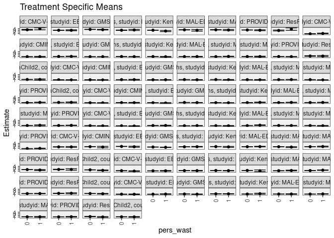

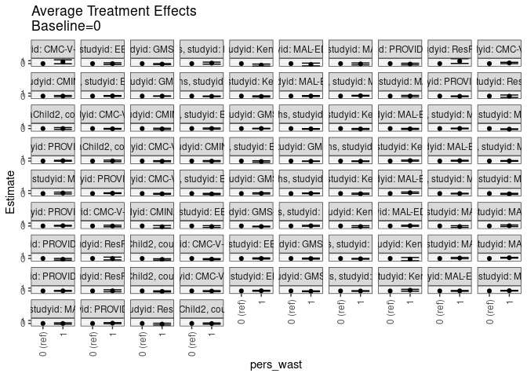

[figure not shown]

## Results Table

### Parameter: TSM

| agecat | studyid | country | intervention_level | baseline_level | estimate | ci_lower | ci_upper |
| --- | --- | --- | --- | --- | --- | --- | --- |
| 0-3 months | CMC-V-BCS-2002 | INDIA | 0 | NA | 3.3958045 | 3.1710366 | 3.6205723 |
| 0-3 months | CMC-V-BCS-2002 | INDIA | 1 | NA | 4.0253278 | 3.3785106 | 4.6721450 |
| 0-3 months | EE | PAKISTAN | 0 | NA | 3.0785647 | 2.9924082 | 3.1647211 |
| 0-3 months | EE | PAKISTAN | 1 | NA | 3.0631580 | 2.7801340 | 3.3461820 |
| 0-3 months | GMS-Nepal | NEPAL | 0 | NA | 3.6184113 | 3.5661013 | 3.6707213 |
| 0-3 months | GMS-Nepal | NEPAL | 1 | NA | 3.4506744 | 3.2683289 | 3.6330199 |
| 0-3 months | IRC | INDIA | 0 | NA | 3.1087411 | 2.9942066 | 3.2232757 |
| 0-3 months | IRC | INDIA | 1 | NA | 3.2762856 | 2.9457273 | 3.6068440 |
| 0-3 months | Keneba | GAMBIA | 0 | NA | 3.1190684 | 3.0716901 | 3.1664467 |
| 0-3 months | Keneba | GAMBIA | 1 | NA | 2.6020227 | 2.2515277 | 2.9525177 |
| 0-3 months | MAL-ED | BANGLADESH | 0 | NA | 3.3481181 | 3.2823621 | 3.4138742 |
| 0-3 months | MAL-ED | BANGLADESH | 1 | NA | 3.0358618 | 2.5584441 | 3.5132795 |
| 0-3 months | MAL-ED | INDIA | 0 | NA | 3.3562201 | 3.2537360 | 3.4587043 |
| 0-3 months | MAL-ED | INDIA | 1 | NA | 3.2436736 | 2.9285267 | 3.5588205 |
| 0-3 months | PROVIDE | BANGLADESH | 0 | NA | 3.2613632 | 3.2241344 | 3.2985919 |
| 0-3 months | PROVIDE | BANGLADESH | 1 | NA | 3.1042582 | 2.8262704 | 3.3822460 |
| 0-3 months | ResPak | PAKISTAN | 0 | NA | 2.9384679 | 2.6492438 | 3.2276920 |
| 0-3 months | ResPak | PAKISTAN | 1 | NA | 3.8074994 | 3.0403193 | 4.5746795 |
| 3-6 months | CMC-V-BCS-2002 | INDIA | 0 | NA | 1.8042856 | 1.6950585 | 1.9135128 |
| 3-6 months | CMC-V-BCS-2002 | INDIA | 1 | NA | 1.8008134 | 1.5392723 | 2.0623545 |
| 3-6 months | CMIN | BANGLADESH | 0 | NA | 1.9623847 | 1.8930298 | 2.0317395 |
| 3-6 months | CMIN | BANGLADESH | 1 | NA | 1.6934503 | 1.2562597 | 2.1306410 |
| 3-6 months | EE | PAKISTAN | 0 | NA | 2.1076096 | 2.0496892 | 2.1655299 |
| 3-6 months | EE | PAKISTAN | 1 | NA | 1.9071628 | 1.5948871 | 2.2194386 |
| 3-6 months | GMS-Nepal | NEPAL | 0 | NA | 1.7296832 | 1.6878472 | 1.7715192 |
| 3-6 months | GMS-Nepal | NEPAL | 1 | NA | 1.5516870 | 1.4457360 | 1.6576381 |
| 3-6 months | IRC | INDIA | 0 | NA | 1.8684459 | 1.8000470 | 1.9368448 |
| 3-6 months | IRC | INDIA | 1 | NA | 1.9321769 | 1.7600663 | 2.1042874 |
| 3-6 months | Keneba | GAMBIA | 0 | NA | 1.9988507 | 1.9592555 | 2.0384458 |
| 3-6 months | Keneba | GAMBIA | 1 | NA | 1.8057108 | 1.5146602 | 2.0967614 |

[output cut: 138 more lines]

### Parameter: E(Y)

| agecat | studyid | country | intervention_level | baseline_level | estimate | ci_lower | ci_upper |
| --- | --- | --- | --- | --- | --- | --- | --- |
| 0-3 months | CMC-V-BCS-2002 | INDIA | NA | NA | 3.4601875 | 3.2440906 | 3.6762845 |
| 0-3 months | EE | PAKISTAN | NA | NA | 3.0775986 | 2.9949164 | 3.1602807 |
| 0-3 months | GMS-Nepal | NEPAL | NA | NA | 3.5989683 | 3.5479067 | 3.6500300 |
| 0-3 months | IRC | INDIA | NA | NA | 3.1381505 | 3.0271308 | 3.2491703 |
| 0-3 months | Keneba | GAMBIA | NA | NA | 3.1026151 | 3.0551419 | 3.1500882 |
| 0-3 months | MAL-ED | BANGLADESH | NA | NA | 3.3391231 | 3.2734666 | 3.4047796 |
| 0-3 months | MAL-ED | INDIA | NA | NA | 3.3482250 | 3.2503342 | 3.4461159 |
| 0-3 months | PROVIDE | BANGLADESH | NA | NA | 3.2576810 | 3.2206777 | 3.2946843 |
| 0-3 months | ResPak | PAKISTAN | NA | NA | 3.0164579 | 2.7387383 | 3.2941775 |
| 3-6 months | CMC-V-BCS-2002 | INDIA | NA | NA | 1.8037880 | 1.7029866 | 1.9045894 |
| 3-6 months | CMIN | BANGLADESH | NA | NA | 1.9478477 | 1.8775639 | 2.0181315 |
| 3-6 months | EE | PAKISTAN | NA | NA | 2.0947237 | 2.0366412 | 2.1528063 |
| 3-6 months | GMS-Nepal | NEPAL | NA | NA | 1.7095685 | 1.6702436 | 1.7488934 |
| 3-6 months | IRC | INDIA | NA | NA | 1.8792287 | 1.8153323 | 1.9431250 |
| 3-6 months | Keneba | GAMBIA | NA | NA | 1.9924313 | 1.9529066 | 2.0319559 |
| 3-6 months | MAL-ED | BANGLADESH | NA | NA | 1.9276407 | 1.8774065 | 1.9778750 |
| 3-6 months | MAL-ED | INDIA | NA | NA | 1.8922980 | 1.8286780 | 1.9559180 |
| 3-6 months | MAL-ED | NEPAL | NA | NA | 1.9644601 | 1.9083113 | 2.0206088 |
| 3-6 months | PROVIDE | BANGLADESH | NA | NA | 1.9657457 | 1.9318660 | 1.9996254 |
| 3-6 months | ResPak | PAKISTAN | NA | NA | 2.0482494 | 1.9118457 | 2.1846530 |
| 3-6 months | TanzaniaChild2 | TANZANIA, UNITED REPUBLIC OF | NA | NA | 1.7951754 | 1.7593106 | 1.8310401 |
| 6-9 months | CMC-V-BCS-2002 | INDIA | NA | NA | 1.2141990 | 1.1366726 | 1.2917254 |
| 6-9 months | EE | PAKISTAN | NA | NA | 1.1779411 | 1.1309380 | 1.2249441 |
| 6-9 months | GMS-Nepal | NEPAL | NA | NA | 1.3171992 | 1.2762953 | 1.3581032 |
| 6-9 months | IRC | INDIA | NA | NA | 1.3728678 | 1.3241483 | 1.4215872 |
| 6-9 months | Keneba | GAMBIA | NA | NA | 1.4104042 | 1.3586776 | 1.4621308 |
| 6-9 months | MAL-ED | INDIA | NA | NA | 1.2462236 | 1.1943701 | 1.2980772 |
| 6-9 months | MAL-ED | NEPAL | NA | NA | 1.3571408 | 1.3129874 | 1.4012943 |
| 6-9 months | PROVIDE | BANGLADESH | NA | NA | 1.2824185 | 1.2571827 | 1.3076542 |
| 6-9 months | ResPak | PAKISTAN | NA | NA | 1.4374407 | 1.3330612 | 1.5418202 |

[output cut: 54 more lines]

### Parameter: ATE

| agecat | studyid | country | intervention_level | baseline_level | estimate | ci_lower | ci_upper |
| --- | --- | --- | --- | --- | --- | --- | --- |
| 0-3 months | CMC-V-BCS-2002 | INDIA | 0 | 0 | 0.0000000 | 0.0000000 | 0.0000000 |
| 0-3 months | CMC-V-BCS-2002 | INDIA | 1 | 0 | 0.6295233 | -0.0552344 | 1.3142810 |
| 0-3 months | EE | PAKISTAN | 0 | 0 | 0.0000000 | 0.0000000 | 0.0000000 |
| 0-3 months | EE | PAKISTAN | 1 | 0 | -0.0154067 | -0.3112538 | 0.2804404 |
| 0-3 months | GMS-Nepal | NEPAL | 0 | 0 | 0.0000000 | 0.0000000 | 0.0000000 |
| 0-3 months | GMS-Nepal | NEPAL | 1 | 0 | -0.1677369 | -0.3574372 | 0.0219635 |
| 0-3 months | IRC | INDIA | 0 | 0 | 0.0000000 | 0.0000000 | 0.0000000 |
| 0-3 months | IRC | INDIA | 1 | 0 | 0.1675445 | -0.1822940 | 0.5173830 |
| 0-3 months | Keneba | GAMBIA | 0 | 0 | 0.0000000 | 0.0000000 | 0.0000000 |
| 0-3 months | Keneba | GAMBIA | 1 | 0 | -0.5170457 | -0.8707284 | -0.1633630 |
| 0-3 months | MAL-ED | BANGLADESH | 0 | 0 | 0.0000000 | 0.0000000 | 0.0000000 |
| 0-3 months | MAL-ED | BANGLADESH | 1 | 0 | -0.3122563 | -0.7941811 | 0.1696685 |
| 0-3 months | MAL-ED | INDIA | 0 | 0 | 0.0000000 | 0.0000000 | 0.0000000 |
| 0-3 months | MAL-ED | INDIA | 1 | 0 | -0.1125465 | -0.4439384 | 0.2188453 |
| 0-3 months | PROVIDE | BANGLADESH | 0 | 0 | 0.0000000 | 0.0000000 | 0.0000000 |
| 0-3 months | PROVIDE | BANGLADESH | 1 | 0 | -0.1571050 | -0.4375745 | 0.1233646 |
| 0-3 months | ResPak | PAKISTAN | 0 | 0 | 0.0000000 | 0.0000000 | 0.0000000 |
| 0-3 months | ResPak | PAKISTAN | 1 | 0 | 0.8690315 | 0.0491438 | 1.6889192 |
| 3-6 months | CMC-V-BCS-2002 | INDIA | 0 | 0 | 0.0000000 | 0.0000000 | 0.0000000 |
| 3-6 months | CMC-V-BCS-2002 | INDIA | 1 | 0 | -0.0034723 | -0.2869054 | 0.2799608 |
| 3-6 months | CMIN | BANGLADESH | 0 | 0 | 0.0000000 | 0.0000000 | 0.0000000 |
| 3-6 months | CMIN | BANGLADESH | 1 | 0 | -0.2689343 | -0.7115919 | 0.1737233 |
| 3-6 months | EE | PAKISTAN | 0 | 0 | 0.0000000 | 0.0000000 | 0.0000000 |
| 3-6 months | EE | PAKISTAN | 1 | 0 | -0.2004468 | -0.5180486 | 0.1171551 |
| 3-6 months | GMS-Nepal | NEPAL | 0 | 0 | 0.0000000 | 0.0000000 | 0.0000000 |
| 3-6 months | GMS-Nepal | NEPAL | 1 | 0 | -0.1779962 | -0.2919079 | -0.0640845 |
| 3-6 months | IRC | INDIA | 0 | 0 | 0.0000000 | 0.0000000 | 0.0000000 |
| 3-6 months | IRC | INDIA | 1 | 0 | 0.0637310 | -0.1214728 | 0.2489348 |
| 3-6 months | Keneba | GAMBIA | 0 | 0 | 0.0000000 | 0.0000000 | 0.0000000 |
| 3-6 months | Keneba | GAMBIA | 1 | 0 | -0.1931399 | -0.4868715 | 0.1005917 |

[output cut: 138 more lines]

### Parameter: PAR

| agecat | studyid | country | intervention_level | baseline_level | estimate | ci_lower | ci_upper |
| --- | --- | --- | --- | --- | --- | --- | --- |
| 0-3 months | CMC-V-BCS-2002 | INDIA | 0 | NA | 0.0643831 | -0.0163082 | 0.1450743 |
| 0-3 months | EE | PAKISTAN | 0 | NA | -0.0009661 | -0.0195223 | 0.0175902 |
| 0-3 months | GMS-Nepal | NEPAL | 0 | NA | -0.0194430 | -0.0419221 | 0.0030362 |
| 0-3 months | IRC | INDIA | 0 | NA | 0.0294094 | -0.0323363 | 0.0911551 |
| 0-3 months | Keneba | GAMBIA | 0 | NA | -0.0164533 | -0.0287765 | -0.0041301 |
| 0-3 months | MAL-ED | BANGLADESH | 0 | NA | -0.0089950 | -0.0243582 | 0.0063682 |
| 0-3 months | MAL-ED | INDIA | 0 | NA | -0.0079951 | -0.0319084 | 0.0159182 |
| 0-3 months | PROVIDE | BANGLADESH | 0 | NA | -0.0036821 | -0.0109320 | 0.0035677 |
| 0-3 months | ResPak | PAKISTAN | 0 | NA | 0.0779900 | -0.0141609 | 0.1701409 |
| 3-6 months | CMC-V-BCS-2002 | INDIA | 0 | NA | -0.0004977 | -0.0411202 | 0.0401249 |
| 3-6 months | CMIN | BANGLADESH | 0 | NA | -0.0145370 | -0.0400268 | 0.0109528 |
| 3-6 months | EE | PAKISTAN | 0 | NA | -0.0128859 | -0.0341024 | 0.0083307 |
| 3-6 months | GMS-Nepal | NEPAL | 0 | NA | -0.0201147 | -0.0339630 | -0.0062664 |
| 3-6 months | IRC | INDIA | 0 | NA | 0.0107828 | -0.0206407 | 0.0422062 |
| 3-6 months | Keneba | GAMBIA | 0 | NA | -0.0064194 | -0.0163512 | 0.0035124 |
| 3-6 months | MAL-ED | BANGLADESH | 0 | NA | 0.0017715 | -0.0032795 | 0.0068224 |
| 3-6 months | MAL-ED | INDIA | 0 | NA | -0.0156180 | -0.0398885 | 0.0086526 |
| 3-6 months | MAL-ED | NEPAL | 0 | NA | 0.0016428 | -0.0052967 | 0.0085823 |
| 3-6 months | PROVIDE | BANGLADESH | 0 | NA | -0.0065628 | -0.0145219 | 0.0013962 |
| 3-6 months | ResPak | PAKISTAN | 0 | NA | -0.0013447 | -0.0459142 | 0.0432247 |
| 3-6 months | TanzaniaChild2 | TANZANIA, UNITED REPUBLIC OF | 0 | NA | -0.0092291 | -0.0161928 | -0.0022653 |
| 6-9 months | CMC-V-BCS-2002 | INDIA | 0 | NA | -0.0357684 | -0.0654419 | -0.0060949 |
| 6-9 months | EE | PAKISTAN | 0 | NA | 0.0004662 | -0.0126358 | 0.0135681 |
| 6-9 months | GMS-Nepal | NEPAL | 0 | NA | -0.0042379 | -0.0226797 | 0.0142040 |
| 6-9 months | IRC | INDIA | 0 | NA | -0.0196372 | -0.0407844 | 0.0015100 |
| 6-9 months | Keneba | GAMBIA | 0 | NA | -0.0063577 | -0.0228121 | 0.0100967 |
| 6-9 months | MAL-ED | INDIA | 0 | NA | 0.0116796 | -0.0062781 | 0.0296373 |
| 6-9 months | MAL-ED | NEPAL | 0 | NA | 0.0067118 | 0.0003445 | 0.0130790 |
| 6-9 months | PROVIDE | BANGLADESH | 0 | NA | 0.0007258 | -0.0026185 | 0.0040701 |
| 6-9 months | ResPak | PAKISTAN | 0 | NA | 0.0059498 | -0.0338933 | 0.0457929 |

[output cut: 54 more lines]